# DRHotNet: An R package for detecting differential risk hotspots on a linear network

## Choosing *k* and *n*

Remember that a higher value of either `k` or `n` represents using a more stringent criterion regarding hotspot detection. This is illustrated through the four maps available in Figure 4, which can be generated with the function `plothot` of *DRHotNet*. For instance, as in the following example for the object `hotspots` created previously (which corresponds to Figure 4d):

```r
> plothot(X = X.chicago, hotspots = hotspots_persons)
```

Indeed, Figure 4 shows the differential risk hotspots that `drhot` detects for the choices of `k = 0.5` and `n = 20` (Figure 4a), `k = 1.5` and `n = 20` (Figure 4b), `k = 1` and `n = 10` (Figure 4c), and `k = 1` and `n = 30` (Figure 4d). Two of these combinations of conditions on $k$ and $n$ are implicitly represented by the other two. Consequently, the differential risk hotspots shown in Figure 4b are contained in Figure 4a, and those in Figure 4d are contained in Figure 4c. The choice of `k = 1` and `n = 30` leads to the highest global $\mathrm{PAI}_{t}$ among the four combinations of parameters indicated with the value of 12.1 mentioned before. In this regard, we recommend performing a sensitivity analysis on the values of $k$ and $n$ to decide which combination is more convenient. The sensitivity analysis carried out by (Briz-Redón, Martı́nez-Ruiz, and Montes 2019a) yielded that a choice around $k=1.5$ and $n=45$ was optimal in terms of the $\mathrm{PAI}_{t}$ for the traffic accident dataset that was investigated. However, each dataset should require a specific analysis.

Thus, a sensitivity analysis on $k$ and $n$ can be carried out with the function `drsens`. The user has to provide a point pattern (`X`), an object containing the relative probabilities of a type of event along the network (`rel_probs`) and a set of values for $k$ and $n$ (`ks` and `ns`, respectively):

```r
> sensitivity_analysis <- drsens(X = X.chicago,
                                 rel_prob = rel_probs_persons,
                                 ks = seq(0,3,0.5),
                                 ns = seq(10,30,5))
> sensitivity_analysis
        n = 10 n = 15 n = 20 n = 25 n = 30
k = 0     3.34   5.07   6.75  12.35  12.05
k = 0.5   4.47   6.52   7.92  12.82  12.05
k = 1     5.15   8.62   8.92  10.93  12.05
k = 1.5   5.94   9.12  10.89  10.88  13.70
k = 2     2.16  10.06     NA     NA     NA
k = 2.5     NA     NA     NA     NA     NA
k = 3       NA     NA     NA     NA     NA
```

The output from `drsens` is a matrix that contains the $\mathrm{PAI}_{t}$ values that correspond to each combination of $k$ and $n$ indicated by `ks` and `ns`. A `NA` value represents that no differential risk hotspots can be found for such a combination of parameters. According to this matrix, the highest $\mathrm{PAI}_{t}$ value is achieved for $k=1.5$ and $n=30$.

Therefore, one can choose the values of $k$ and $n$ that maximize the $\mathrm{PAI}_{t}$ (considering the parameters provided in `ks` and `ns`) to determine the final set of differential risk hotspots. However, this criteria may sometimes lead to detecting a very low number of differential risks hotspots and hence to miss zones of the network that may also deserve some attention. Hence, a more conservative approach could be considering several combinations of $k$ and $n$ that yield some of the highest values of $\mathrm{PAI}_{t}$ and explore each set of differential risk hotspots associated. Then, one could investigate the output of `drsummary` for each combination of parameters (including the computation of $p$-values) to better decide which zones of the network are relevant for the type of event of interest.

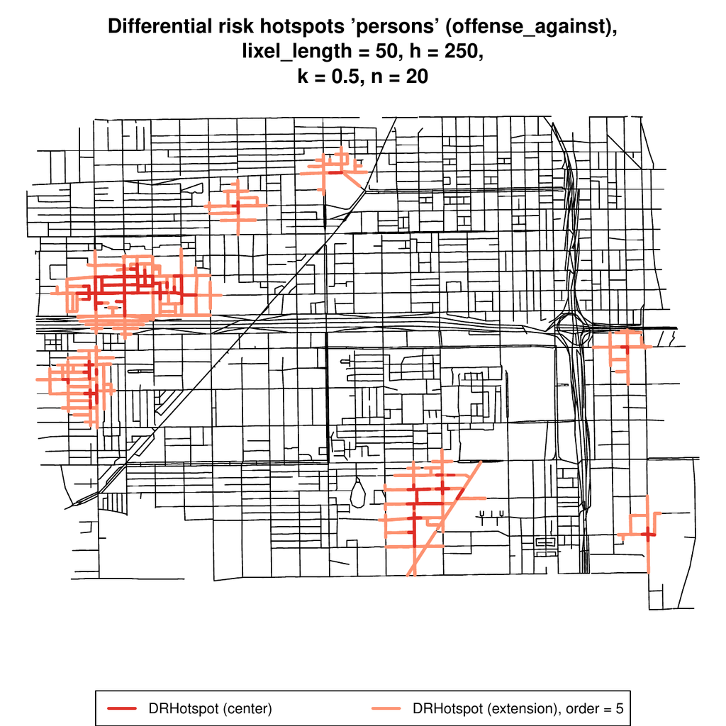

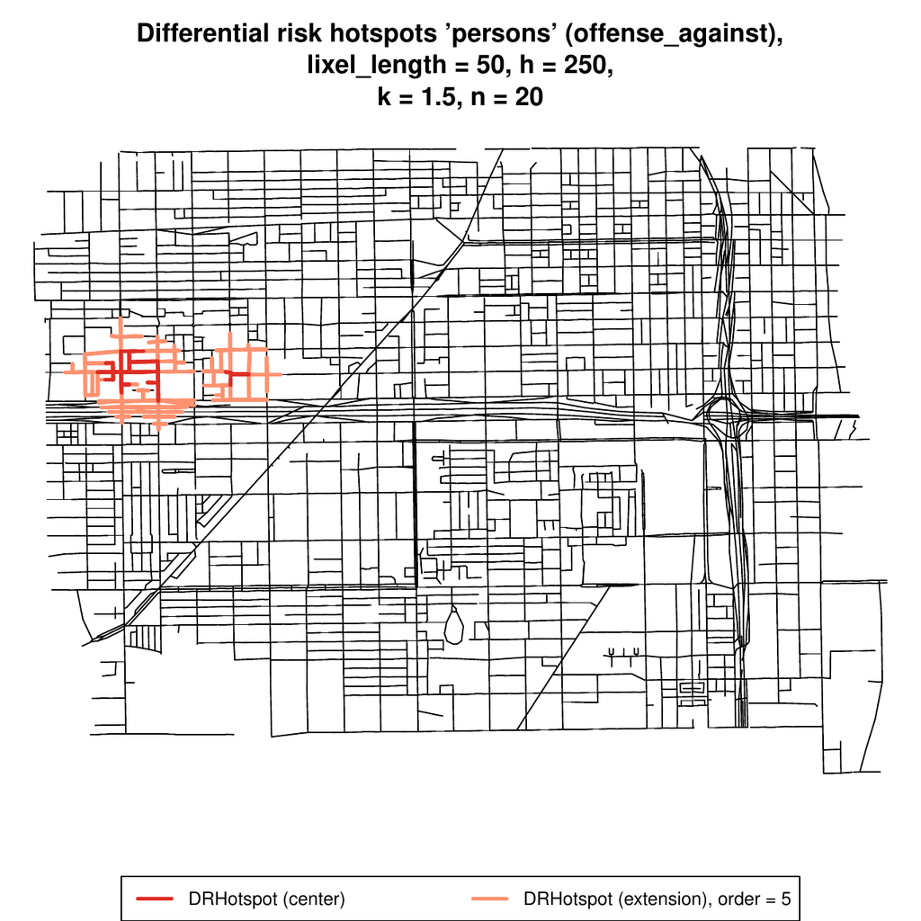

(a)

(b)

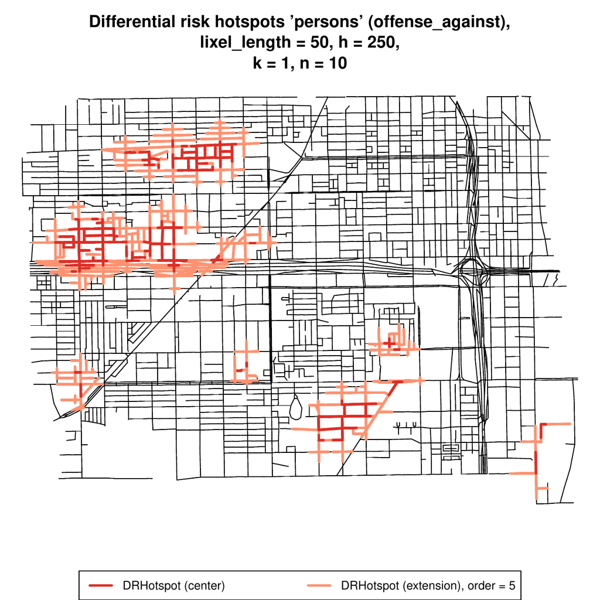

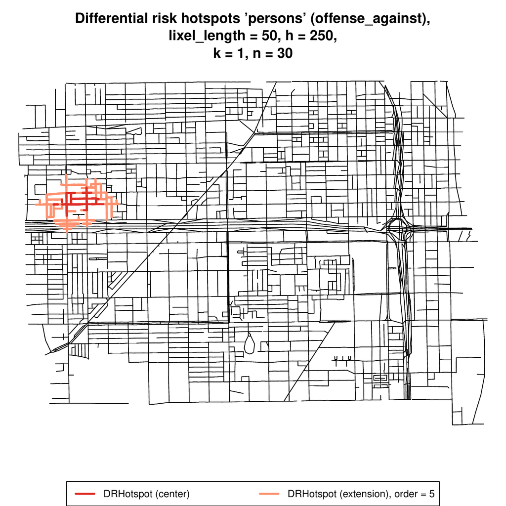

(c)

(d)

Figure 4: Outputs from the function `plothot` for the following choices of *k* and *n*: *k* = 0.5 and *n* = 20 (a), *k* = 1.5 and *n* = 20 (b), *k* = 1 and *n* = 10 (c), and *k* = 1 and *n* = 30 (d).

## Other applications of the methodology

This final section shows the results that are obtained for other type of events for comparative purposes. First, the marks `X.chicago` are recoded into binary outcomes as follows:

```r
> year_after_2012 <- ifelse(X.chicago$data$year>2012, "Yes", "No")
> month_winter <- ifelse(X.chicago$data$month%in%c(12,1,2), "Yes", "No")
> hour_21_3 <- ifelse(X.chicago$data$hour%in%c(21:23,0:3), "Yes", "No")
> marks(X.chicago) <- data.frame(as.data.frame(marks(X.chicago)),
                                 year_after_2012 = year_after_2012,
                                 month_winter = month_winter,
                                 hour_21_3 = hour_21_3)
```

The relative probability surfaces have to be computed. We used the same values for `lixel.length` and `h` than in the previous examples.

```r
> rel_probs_after_2012 <- relpnet(X = X.chicago,
                                  lixel_length = 50,
                                  h = 250,
                                  mark = "year_after_2012",
                                  category_mark = "Yes")
> rel_probs_winter <- relpnet(X = X.chicago,
                              lixel_length = 50,
                              h = 250,
                              mark = "month_winter",
                              category_mark = "Yes")
> rel_probs_21_3 <- relpnet(X = X.chicago,
                            lixel_length = 50,
                            h = 250,
                            mark = "hour_21_3",
                            category_mark = "Yes")
```

The corresponding sensitivity analyses are carried out:

```r
> sensitivity_after_2012 <- drsens(X = X.chicago,
                                   rel_prob = rel_probs_after_2012,
                                   ks = seq(0,3,0.5),
                                   ns = seq(10,30,5))
> sensitivity_after_2012
        n = 10 n = 15 n = 20 n = 25 n = 30
k = 0     2.47   3.35   4.59   6.36  10.96
k = 0.5   3.08   4.28   7.11  14.00  15.09
k = 1     2.84   4.38   8.33  25.76  29.98
k = 1.5   2.65   4.63   7.03   0.00   0.00
k = 2     2.24   0.00     NA     NA     NA
k = 2.5     NA     NA     NA     NA     NA
k = 3       NA     NA     NA     NA     NA
> sensitivity_winter <- drsens(X = X.chicago,
                               rel_prob = rel_probs_winter,
                               ks = seq(0,3,0.5),
                               ns = seq(10,30,5))
> sensitivity_winter
        n = 10 n = 15 n = 20 n = 25 n = 30
k = 0     2.75   3.63   4.81   5.17   4.86
k = 0.5   2.83   3.60   4.41   8.35   0.00
k = 1     3.62   3.86   0.00   0.00     NA
k = 1.5   7.59   8.56   0.00     NA     NA
k = 2       NA     NA     NA     NA     NA
k = 2.5     NA     NA     NA     NA     NA
k = 3       NA     NA     NA     NA     NA
> sensitivity_21_3 <- drsens(X = X.chicago,
                             rel_prob = rel_probs_21_3,
                             ks = seq(0,3,0.5),
                             ns = seq(10,30,5))
> sensitivity_21_3
        n = 10 n = 15 n = 20 n = 25 n = 30
k = 0     2.86   4.55   5.41   6.75   7.78
k = 0.5   3.50   5.21   6.02   7.11   7.34
k = 1     4.17   5.90   4.84   0.00   0.00
k = 1.5   4.78   6.92   5.52     NA     NA
k = 2     5.14   5.64   3.00     NA     NA
k = 2.5   4.59   1.75   0.00     NA     NA
k = 3       NA     NA     NA     NA     NA
```

The highest $\mathrm{PAI}_{t}$ values for `year_after_2012`, `month_winter`, and `hour_21_3` are 29.98, 8.56, and 7.78, respectively. The differential risk hotspots that are obtained for the combination of $k$ and $n$ that lead to these $\mathrm{PAI}_{t}$ values can be visualized with `plothot` (Figure 5):

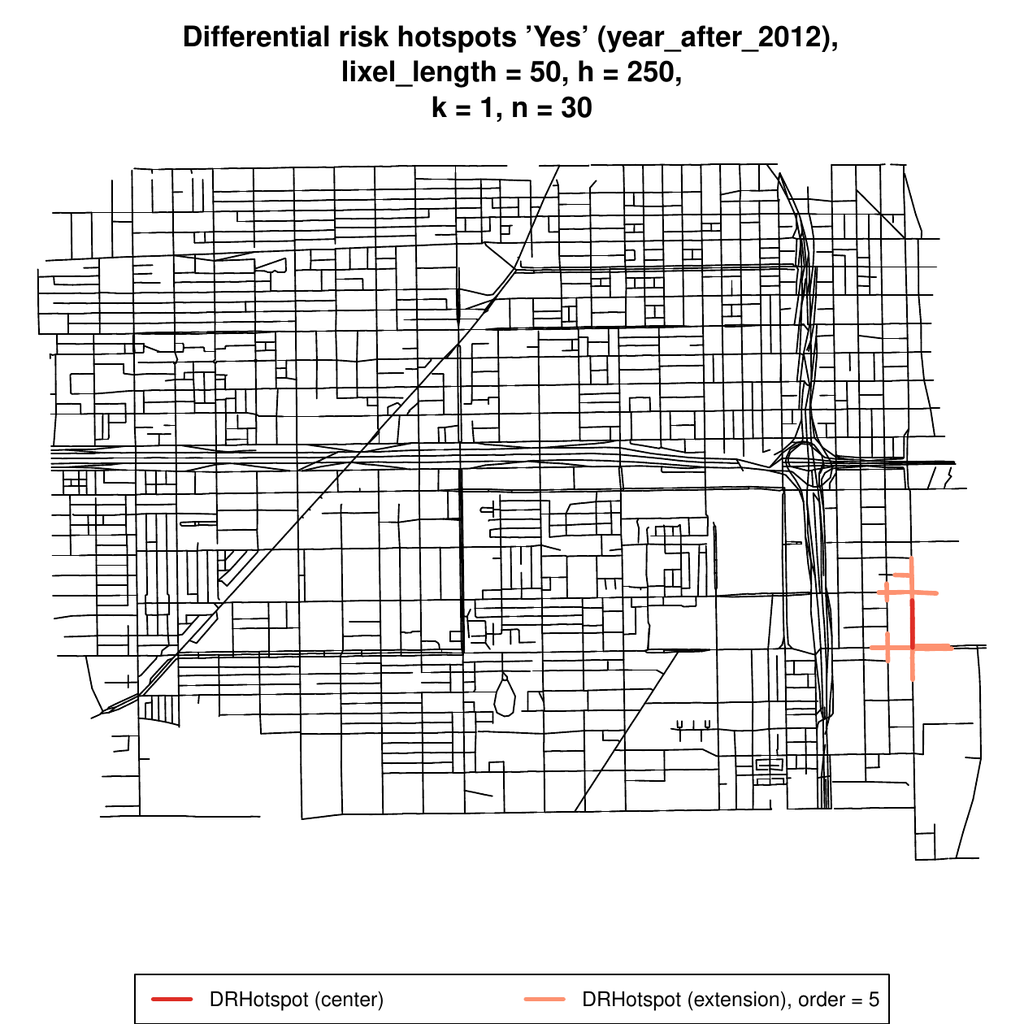

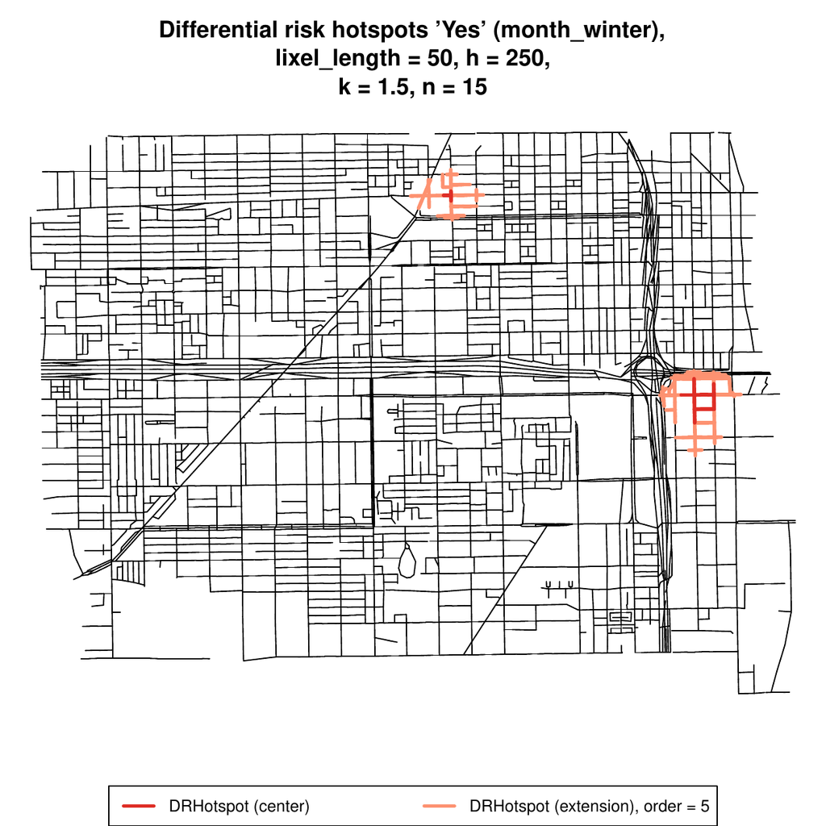

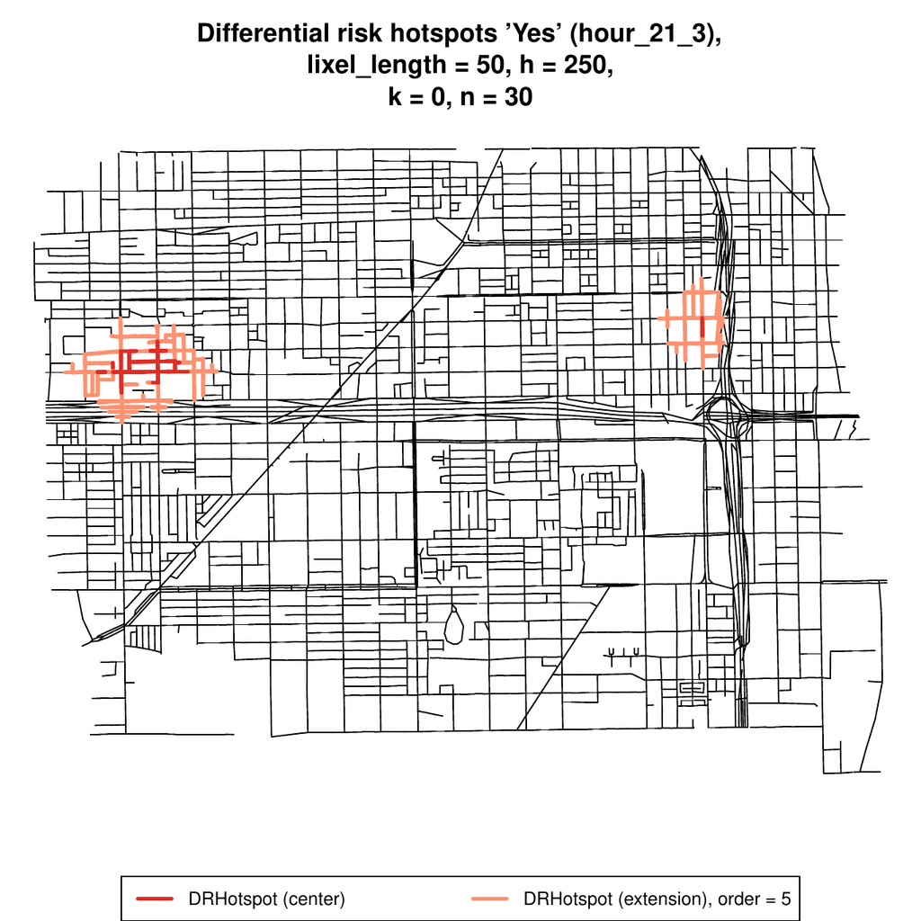

```r
> hotspots_after_2012 <- drhot(X = X.chicago,
                               rel_prob = rel_probs_after_2012,
                               k = 1,
                               n = 30)
> plothot(X = X.chicago, hotspots_after_2012)

> hotspots_winter <- drhot(X = X.chicago,
                           rel_prob = rel_probs_winter,
                           k = 1.5,
                           n = 15)
> plothot(X = X.chicago, hotspots_winter)

> hotspots_21_3 <- drhot(X = X.chicago,
                         rel_prob = rel_probs_21_3,
                         k = 0,
                         n = 30)
> plothot(X = X.chicago, hotspots_21_3)
```

(a)

(b)

(c)

Figure 5: Outputs from the function `plothot` for the marks `year_after_2012`, `month_winter`, and `hour_21_3` and the categorical value `Yes` for the three, considering the combinations of *k* and *n* that maximize the PAI<sub>*t*</sub> (for the values of *k* and *n* tested).

# Summary

The R package *DRHotNet* for detecting differential risk hotspots on linear networks has been described. The use of linear networks in the context of hotspot detection is becoming more important over the years, particularly in the fields of criminology and traffic safety. In addition, it is also of great interest sometimes to detect zones of a linear network where a certain type of event is especially overrepresented. Hence, *DRHotNet* consists of an easy-to-use tool implemented in R to accurately locate the microzones of a linear network where the incidence of a type of event is considerably higher than in the rest of it.

Allévius, Benjamin. 2018. “Scanstatistics: Space-Time Anomaly Detection Using Scan Statistics.” *The Journal of Open Source Software* 3: 515.

Andresen, Martin A, Andrea S Curman, and Shannon J Linning. 2017. “The Trajectories of Crime at Places: Understanding the Patterns of Disaggregated Crime Types.” *Journal of Quantitative Criminology* 33 (3): 427–49.

Ang, Qi Wei, Adrian Baddeley, and Gopalan Nair. 2012. “Geometrically Corrected Second Order Analysis of Events on a Linear Network, with Applications to Ecology and Criminology.” *Scandinavian Journal of Statistics* 39 (4): 591–617.

Anselin, Luc. 1995. “Local Indicators of Spatial Association—LISA.” *Geographical Analysis* 27 (2): 93–115.

Ashby, Matthew PJ. 2019. “Studying Crime and Place with the Crime Open Database: Social and Behavioural Scienes.” *Research Data Journal for the Humanities and Social Sciences* 1 (aop): 1–16.

Baddeley, Adrian, Gopalan Nair, Suman Rakshit, and Greg McSwiggan. 2017. “‘Stationary’ Point Processes Are Uncommon on Linear Networks.” *Stat* 6 (1): 68–78.

Baddeley, Adrian, Ege Rubak, and Rolf Turner. 2015. *Spatial Point Patterns: Methodology and Applications with r*. CRC Press.

Bivand, Roger S., Edzer Pebesma, and Virgilio Gómez-Rubio. 2013. *Applied Spatial Data Analysis with R, Second Edition*. Springer, NY. http://www.asdar-book.org/.

Bivand, Roger, and Nicholas Lewin-Koh. 2017. *Maptools: Tools for Reading and Handling Spatial Objects*. https://CRAN.R-project.org/package=maptools.

Bivand, Roger, and Colin Rundel. 2020. *rgeos: Interface to Geometry Engine - Open Source (’GEOS’)*. https://CRAN.R-project.org/package=rgeos.

Bı́l, Michal, Richard Andrášik, and Zbyněk Janoška. 2013. “Identification of Hazardous Road Locations of Traffic Accidents by Means of Kernel Density Estimation and Cluster Significance Evaluation.” *Accident Analysis & Prevention* 55: 265–73.

Bı́l, Michal, Richard Andrášik, Tomáš Svoboda, and Jiřı́ Sedonı́k. 2016. “The KDE+ software: a tool for effective identification and ranking of animal-vehicle collision hotspots along networks.” *Landscape Ecology* 31 (2): 231–37.

Briz-Redón, Álvaro. 2019. “SpNetPrep: An R package using Shiny to facilitate spatial statistics on road networks.” *Research Ideas and Outcomes* 5: e33521.

Briz-Redón, Álvaro, Francisco Martı́nez-Ruiz, and Francisco Montes. 2019a. “Identification of Differential Risk Hotspots for Collision and Vehicle Type in a Directed Linear Network.” *Accident Analysis & Prevention* 132: 105278.

———. 2019b. “Spatial Analysis of Traffic Accidents Near and Between Road Intersections in a Directed Linear Network.” *Accident Analysis & Prevention* 132: 105252.

Chainey, Spencer, Lisa Tompson, and Sebastian Uhlig. 2008. “The Utility of Hotspot Mapping for Predicting Spatial Patterns of Crime.” *Security Journal* 21 (1-2): 4–28.

Deng, Min, Xuexi Yang, Yan Shi, Jianya Gong, Yang Liu, and Huimin Liu. 2019. “A Density-Based Approach for Detecting Network-Constrained Clusters in Spatial Point Events.” *International Journal of Geographical Information Science* 33 (3): 466–88.

Diggle, Peter J. 2013. *Statistical Analysis of Spatial and Spatio-Temporal Point Patterns*. CRC press.

Douglas, David H, and Thomas K Peucker. 1973. “Algorithms for the Reduction of the Number of Points Required to Represent a Digitized Line or Its Caricature.” *Cartographica: The International Journal for Geographic Information and Geovisualization* 10 (2): 112–22.

Drawve, Grant, and Alese Wooditch. 2019. “A Research Note on the Methodological and Theoretical Considerations for Assessing Crime Forecasting Accuracy with the Predictive Accuracy Index.” *Journal of Criminal Justice*, 101625.

Eckardt, Matthias, and Jorge Mateu. 2018. “Point Patterns Occurring on Complex Structures in Space and Space-Time: An Alternative Network Approach.” *Journal of Computational and Graphical Statistics* 27 (2): 312–22.

———. 2021. “Second-Order and Local Characteristics of Network Intensity Functions.” *TEST* 30 (2): 318–40.

Getis, Arthur, and JK Ord. 1992. “The Analysis of Spatial Association by Use of Distance Statistics.” *Geographical Analysis* 24 (3).

Gómez-Rubio, Virgilio, J Ferrándiz-Ferragud, and Antonio López-Quílez. 2005. “Detecting Clusters of Disease with R.” *Journal of Geographical Systems* 7 (2): 189–206.

Gómez-Rubio, Virgilio, Paula Moraga, John Molitor, and Barry Rowlingson. 2019. “DClusterm: Model-Based Detection of Disease Clusters.” *Journal of Statistical Software, Articles* 90 (14): 1–26. https://doi.org/10.18637/jss.v090.i14.

Grolemund, Garrett, and Hadley Wickham. 2011. “Dates and Times Made Easy with lubridate.” *Journal of Statistical Software* 40 (3): 1–25. http://www.jstatsoft.org/v40/i03/.

Hijmans, Robert J. 2019. *Raster: Geographic Data Analysis and Modeling*. https://CRAN.R-project.org/package=raster.

Kelsall, Julia E, and Peter J Diggle. 1995a. “Kernel Estimation of Relative Risk.” *Bernoulli* 1 (1-2): 3–16.

———. 1995b. “Non-Parametric Estimation of Spatial Variation in Relative Risk.” *Statistics in Medicine* 14 (21-22): 2335–42.

———. 1998. “Spatial Variation in Risk of Disease: A Nonparametric Binary Regression Approach.” *Journal of the Royal Statistical Society: Series C (Applied Statistics)* 47 (4): 559–73.

Kulldorff, Martin. 1997. “A Spatial Scan Statistic.” *Communications in Statistics-Theory and Methods* 26 (6): 1481–96.

Lloyd, Christopher. 2010. *Spatial Data Analysis: An Introduction for GIS Users*. Oxford University Press.

McSwiggan, Greg, Adrian Baddeley, and Gopalan Nair. 2017. “Kernel Density Estimation on a Linear Network.” *Scandinavian Journal of Statistics* 44 (2): 324–45.

———. 2019. “Estimation of Relative Risk for Events on a Linear Network.” *Statistics and Computing*, 1–16.

Meyer, Sebastian, Leonhard Held, and Michael Höhle. 2017. “Spatio-Temporal Analysis of Epidemic Phenomena Using the R Package surveillance.” *Journal of Statistical Software* 77 (11).

Moradi, M Mehdi, Ottmar Cronie, Ege Rubak, Raphael Lachieze-Rey, Jorge Mateu, and Adrian Baddeley. 2019. “Resample-smoothing of Voronoi intensity estimators.” *Statistics and Computing* 29 (5): 995–1010.

Moradi, M Mehdi, Francisco J Rodrı́guez-Cortés, and Jorge Mateu. 2018. “On Kernel-Based Intensity Estimation of Spatial Point Patterns on Linear Networks.” *Journal of Computational and Graphical Statistics* 27 (2): 302–11.

Nie, Ke, Zhensheng Wang, Qingyun Du, Fu Ren, and Qin Tian. 2015. “A Network-Constrained Integrated Method for Detecting Spatial Cluster and Risk Location of Traffic Crash: A Case Study from Wuhan, China.” *Sustainability* 7 (3): 2662–77.

Pebesma, Edzer. 2018. “Simple Features for R: Standardized Support for Spatial Vector Data.” *The R Journal*. https://journal.r-project.org/archive/2018/RJ-2018-009/index.html.

Pebesma, Edzer J., and Roger S. Bivand. 2005. “Classes and Methods for Spatial Data in R.” *R News* 5 (2): 9–13. https://CRAN.R-project.org/doc/Rnews/.

Rakshit, Suman, Adrian Baddeley, and Gopalan Nair. 2019. “Efficient Code for Second Order Analysis of Events on a Linear Network.” *Journal of Statistical Software* 90 (1): 1–37.

Rakshit, Suman, Tilman Davies, M Mehdi Moradi, Greg McSwiggan, Gopalan Nair, Jorge Mateu, and Adrian Baddeley. 2019. “Fast Kernel Smoothing of Point Patterns on a Large Network using Two-dimensional Convolution.” *International Statistical Review*.

Schnell, Cory, Anthony A Braga, and Eric L Piza. 2017. “The influence of community areas, neighborhood clusters, and street segments on the spatial variability of violent crime in Chicago.” *Journal of Quantitative Criminology* 33 (3): 469–96.

Steenbeek, Wouter, and David Weisburd. 2016. “Where the action is in crime? An examination of variability of crime across different spatial units in The Hague, 2001–2009.” *Journal of Quantitative Criminology* 32 (3): 449–69.

van der Meer, Lucas, Lorena Abad, Andrea Gilardi, and Robin Lovelace. 2021. *sfnetworks: Tidy Geospatial Networks*. https://CRAN.R-project.org/package=sfnetworks.

Walker, Kyle. 2016. “tigris: An R package to access and work with geographic data from the US Census Bureau.” *The R Journal* 8 (2): 231–42.

Weisburd, David. 2015. “The Law of Crime Concentration and the Criminology of Place.” *Criminology* 53 (2): 133–57.

Xie, Zhixiao, and Jun Yan. 2008. “Kernel Density Estimation of Traffic Accidents in a Network Space.” *Computers, Environment and Urban Systems* 32 (5): 396–406.

———. 2013. “Detecting Traffic Accident Clusters with Network Kernel Density Estimation and Local Spatial Statistics: An Integrated Approach.” *Journal of Transport Geography* 31: 64–71.